# Finding the association between average SAT math scores and students race composition

## Introduction

As one admission test, the Scholastic Aptitude Test (SAT) is widely used by universities and colleges in the US, it is one of the most important indicators that reflect a student's academic ability. Since SAT is such a critical subject for high school students, a school with a higher average SAT score is more preferred by people than the other schools. According to the data from NECS(National Center for Educational Statistics), Asians and White both have an average SAT math score of more than 557, but Black and Hispanic all have an average SAT score of lower than 490. The data implies that the average SAT score is associated with a student's race. Thus, it would be interesting to find out whether a school's average SAT math score associates with the school's race composition. Thus, in this report, I am going to study the association between a high school's average SAT math score and the race composition of students of the school.

I am going to load a dataset that records average SAT scores for NYC public schools, and plot the histograms of average SAT math scores and four other variables that records the school's race composition. Scatter plots would be shown to naively demonstrate the association between my Y and Xs as well as other visulizations such as histograms and maps. The dataset would be introduced more in details in the Data section, a summary statistics of the dataset would be shown in the Summary Statistics section. The primary plots would be presented and explained in the Preliminary Results section, and some more advanced plots would be shown in the The Message section. Maps can be found in the Map section.

## Project 1

## Data

The data used in this report is obtained from NYC Open Data, it records the average SAT score in every accredited high school in New York City and other relevant information about the school. There are 435 observations in the raw data which the level of observation is school, and the data has a total of 22 variables include the ID.

```python
import geopandas as gpd
import matplotlib.pyplot as plt
import pandas as pd
import numpy as np
import math
from shapely.geometry import Point
from bokeh.io import output_notebook
from bokeh.plotting import figure, ColumnDataSource
from bokeh.io import output_notebook, show, output_file
from bokeh.plotting import figure
from bokeh.models import GeoJSONDataSource, LinearColorMapper, ColorBar, HoverTool
from bokeh.palettes import brewer
output_notebook()
import json

%matplotlib inline
# activate plot theme
import qeds
sat_data = pd.read_csv('C:/Users/11955/Downloads/scores.csv')
sat_data = pd.DataFrame(sat_data)
sat_data.dropna(inplace=True)

sat_data["Percent White"] = sat_data["Percent White"].str.rstrip('%').astype('float') / 100.0
sat_data["Percent Black"] = sat_data["Percent Black"].str.rstrip('%').astype('float') / 100.0
sat_data["Percent Hispanic"] = sat_data["Percent Hispanic"].str.rstrip('%').astype('float') / 100.0
sat_data["Percent Asian"] = sat_data["Percent Asian"].str.rstrip('%').astype('float') / 100.0

sat_data.head(5)
```

```
PROJ: proj_create_from_database: Cannot find proj.db
```

|  | School ID | School Name | Borough | Building Code | Street Address | City | State | Zip Code | Latitude | Longitude | ... | End Time | Student Enrollment | Percent White | Percent Black | Percent Hispanic | Percent Asian | Average Score (SAT Math) | Average Score (SAT Reading) | Average Score (SAT Writing) | Percent Tested |
| --- | --- | --- | --- | --- | --- | --- | --- | --- | --- | --- | --- | --- | --- | --- | --- | --- | --- | --- | --- | --- | --- |
| 2 | 01M539 | New Explorations into Science, Technology and ... | Manhattan | M022 | 111 Columbia Street | Manhattan | NY | 10002 | 40.71873 | -73.97943 | ... | 4:00 PM | 1735.0 | 0.286 | 0.133 | 0.180 | 0.385 | 657.0 | 601.0 | 601.0 | 91.0% |
| 3 | 02M294 | Essex Street Academy | Manhattan | M445 | 350 Grand Street | Manhattan | NY | 10002 | 40.71687 | -73.98953 | ... | 2:45 PM | 358.0 | 0.117 | 0.385 | 0.413 | 0.059 | 395.0 | 411.0 | 387.0 | 78.9% |
| 4 | 02M308 | Lower Manhattan Arts Academy | Manhattan | M445 | 350 Grand Street | Manhattan | NY | 10002 | 40.71687 | -73.98953 | ... | 3:00 PM | 383.0 | 0.031 | 0.282 | 0.569 | 0.086 | 418.0 | 428.0 | 415.0 | 65.1% |
| 5 | 02M545 | High School for Dual Language and Asian Studies | Manhattan | M445 | 350 Grand Street | Manhattan | NY | 10002 | 40.71687 | -73.98953 | ... | 3:35 PM | 416.0 | 0.017 | 0.031 | 0.055 | 0.889 | 613.0 | 453.0 | 463.0 | 95.9% |
| 6 | 01M292 | Henry Street School for International Studies | Manhattan | M056 | 220 Henry Street | Manhattan | NY | 10002 | 40.71376 | -73.98526 | ... | 3:30 PM | 255.0 | 0.039 | 0.244 | 0.566 | 0.132 | 410.0 | 406.0 | 381.0 | 59.7% |

5 rows × 22 columns

The above output is a demonsration of what the raw dataset looks like, it is called table 1. It mainly contains demographic information such as zip code and percent of white students. However, only "Percent White", "Percent Black", "Percent Hispanic", "Percent Asian" are the variables of interest, and "Average Score (SAT Math)" is the response variable.

## Summary Statistics

```python
useful_stat = sat_data.drop(["Zip Code","Latitude","Longitude"], axis = 1)
summary_stat = useful_stat.describe()
summary_stat
```

|  | Student Enrollment | Percent White | Percent Black | Percent Hispanic | Percent Asian | Average Score (SAT Math) | Average Score (SAT Reading) | Average Score (SAT Writing) |
| --- | --- | --- | --- | --- | --- | --- | --- | --- |
| count | 374.000000 | 374.000000 | 374.000000 | 374.000000 | 374.000000 | 374.000000 | 374.000000 | 374.000000 |
| mean | 756.459893 | 0.085246 | 0.353872 | 0.439297 | 0.104126 | 432.719251 | 424.342246 | 418.286096 |
| std | 774.287044 | 0.133592 | 0.253672 | 0.244956 | 0.144006 | 71.916833 | 61.884529 | 64.548388 |
| min | 142.000000 | 0.000000 | 0.000000 | 0.026000 | 0.000000 | 317.000000 | 302.000000 | 284.000000 |
| 25% | 397.250000 | 0.013000 | 0.164000 | 0.208250 | 0.016000 | 386.000000 | 386.000000 | 382.000000 |
| 50% | 482.500000 | 0.026000 | 0.287500 | 0.453000 | 0.042000 | 414.000000 | 412.500000 | 402.500000 |
| 75% | 660.500000 | 0.093750 | 0.501000 | 0.633750 | 0.111500 | 457.250000 | 444.500000 | 436.000000 |
| max | 5447.000000 | 0.799000 | 0.912000 | 1.000000 | 0.889000 | 754.000000 | 697.000000 | 693.000000 |

The above table is called table 2, which shows the summary statistics of the dataset. The row "count" counts the number of observations for each variable, it shows that there are 374 observations. The reason the observation has fewer observations than the raw dataset is that I remove all the NAs in the raw dataset. According to the table, in an average school, there are about 8.52% Whites, 35.4% Blacks, 43.9% Hispanics and 10.4% Asians. The average SAT math score is about 432.72 acroos all NYC high schools.

## Preliminary Results

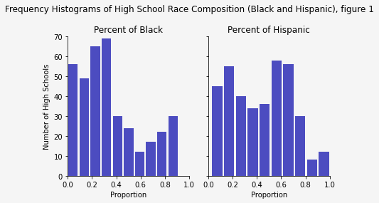

```python
fig, axs = plt.subplots(1,2)
fig.suptitle("Frequency Histograms of High School Race Composition (Black and Hispanic), figure 1")
axs[0].hist(x=sat_data["Percent Black"],bins='auto', color='#0504aa',alpha=0.7, rwidth=0.85)
axs[0].set_title('Percent of Black')
axs[0].set_xlabel('Proportion')
axs[0].set_ylabel('Number of High Schools')
axs[0].spines['right'].set_visible(False)
axs[0].spines['top'].set_visible(False)
axs[0].set_facecolor((0.96, 0.96, 0.96))
axs[0].set_xlim(0,1)
axs[0].set_ylim(0,70)
axs[1].hist(x=sat_data["Percent Hispanic"],bins='auto', color='#0504aa',alpha=0.7, rwidth=0.85)
axs[1].set_title('Percent of Hispanic')
axs[1].set_xlabel('Proportion')
axs[1].spines['right'].set_visible(False)
axs[1].spines['top'].set_visible(False)
axs[1].set_facecolor((0.96, 0.96, 0.96))
axs[1].set_xlim(0,1)
axs[1].set_ylim(0,70)
axs[1].yaxis.set_ticklabels([])

fig.set_facecolor((0.96, 0.96, 0.96))
fig.tight_layout()
```

The above two figures show the distribution of Black students and Hispanic students in NYC high school respectively. According to the left graph, about one-third of NYC high school has more than 40% Black students while about 30 schools have around 85% students as Black. But there are also more than 100 schools that have less than 20% of Black students. Moreover, the graph for Hispanic students has a bimodal distribution, there are similar amounts of high schools which have less than 20% Hispanic students or have about 60% of Hispanic students. Compared to the Black students' distribution, the distribution for Hispanics is more extreme.

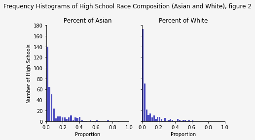

```python
fig, axs = plt.subplots(1,2)
fig.suptitle("Frequency Histograms of High School Race Composition (Asian and White), figure 2")
axs[0].hist(x=sat_data["Percent Asian"],bins='auto', color='#0504aa',alpha=0.7, rwidth=0.85)
axs[0].set_title('Percent of Asian')
axs[0].set_xlabel('Proportion')
axs[0].set_ylabel('Number of High Schools')
axs[0].spines['right'].set_visible(False)
axs[0].spines['top'].set_visible(False)
axs[0].set_facecolor((0.96, 0.96, 0.96))
axs[0].set_xlim(0,1)
axs[0].set_ylim(0,180)
axs[1].hist(x=sat_data["Percent White"],bins='auto', color='#0504aa',alpha=0.7, rwidth=0.85)
axs[1].set_title('Percent of White')
axs[1].set_xlabel('Proportion')
axs[1].spines['right'].set_visible(False)
axs[1].spines['top'].set_visible(False)
axs[1].set_facecolor((0.96, 0.96, 0.96))
axs[1].set_xlim(0,1)
axs[1].set_ylim(0,180)
axs[1].yaxis.set_ticklabels([])

fig.set_facecolor((0.96, 0.96, 0.96))
fig.tight_layout()
```

Figure 2 shows the distribution of Asian students and White students in NYC high school. They have very similar patterns and they are both extremely right-skewed. Most of the NYC high schools have less than 10% of Asian students or White students. About 140 high schools have almost 0% Asian students and about 175 high schools have close to 0% White students. Compares to Blacks and Hispanics, the distribution of Asians and Whites is much more scatter by having a very small number of Asian-intensive schools or White-intensive schools.

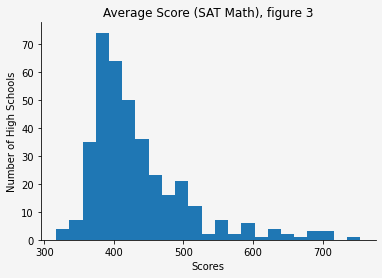

```python
fig, ax = plt.subplots()
sat_data.plot(
    kind="hist", y="Average Score (SAT Math)",
    bins=23, legend=False, density=False, ax=ax
)
ax.set_facecolor((0.96, 0.96, 0.96))
fig.set_facecolor((0.96, 0.96, 0.96))
ax.spines['right'].set_visible(False)
ax.spines['top'].set_visible(False)
ax.set_title("Average Score (SAT Math), figure 3")
ax.set_xlabel("Scores")
ax.set_ylabel('Number of High Schools')
```

This histogram shows the distribution of NYC high school's average SAT math scores, it has a right skewed distribution where most schools have an average math score of around 400. But the highest bar is below the mean (432.72) based on the summary statistics in table 2. Moreover, the distribution of average SAT math scores is very similar to the distribution of White students or Asian students acroos schools.

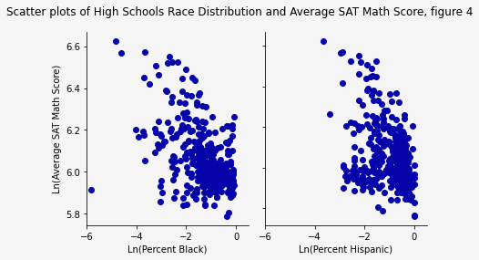

```python
fig, axs = plt.subplots(1,2)
fig.suptitle('Scatter plots of High Schools Race Distribution and Average SAT Math Score, figure 4')
axs[0].plot(np.log(sat_data["Percent Black"]), np.log(sat_data["Average Score (SAT Math)"]), 'o', color='#0504aa')
axs[0].set_xlabel('Ln(Percent Black)')
axs[0].set_ylabel('Ln(Average SAT Math Score)')
axs[0].set_facecolor((0.96, 0.96, 0.96))
axs[0].spines['right'].set_visible(False)
axs[0].spines['top'].set_visible(False)
axs[0].set_xlim(-6,0.5)
axs[1].plot(np.log(sat_data["Percent Hispanic"]), np.log(sat_data["Average Score (SAT Math)"]), 'o', color='#0504aa')
axs[1].set_xlabel('Ln(Percent Hispanic)')
axs[1].set_facecolor((0.96, 0.96, 0.96))
axs[1].spines['right'].set_visible(False)
axs[1].spines['top'].set_visible(False)
axs[1].set_xlim(-6,0.5)
axs[1].yaxis.set_ticklabels([])

fig.set_facecolor((0.96, 0.96, 0.96))
fig.tight_layout()
```

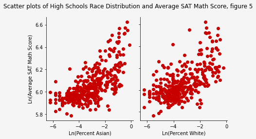

```python
fig, axs = plt.subplots(1,2)
fig.suptitle('Scatter plots of High Schools Race Distribution and Average SAT Math Score, figure 5')
axs[0].plot(np.log(sat_data["Percent Asian"]), np.log(sat_data["Average Score (SAT Math)"]), 'o', color='#c90000')
axs[0].set_xlabel('Ln(Percent Asian)')
axs[0].set_ylabel('Ln(Average SAT Math Score)')
axs[0].spines['right'].set_visible(False)
axs[0].spines['top'].set_visible(False)
axs[0].set_facecolor((0.96, 0.96, 0.96))
axs[1].plot(np.log(sat_data["Percent White"]), np.log(sat_data["Average Score (SAT Math)"]), 'o', color="#c90000")
axs[1].set_xlabel('Ln(Percent White)')
axs[1].spines['right'].set_visible(False)
axs[1].spines['top'].set_visible(False)
axs[1].set_facecolor((0.96, 0.96, 0.96))
axs[1].yaxis.set_ticklabels([])
fig.set_facecolor((0.96, 0.96, 0.96))
fig.tight_layout()
```

Figure 5 shows the relationship between the proportion of Asian students or White students and the high school's average SAT math score. And the proportion of Asian students and the proportion of White students are both positively associated with the high school's average SAT math score. Both plots have a nearly 45-degree upward trend, which means the correlation between the proportion of Asians or Whites and the average SAT math score should be pretty high.

## Project 2

## The Message

High school's average SAT math score differs accroding to its race composition. For example, schools which have around 70% of Asian students and White students on average have a higher average than schools which have only about 20% of Asians and Whites. In other word, schools which have majority of students as Blacks and Hispanic on average have a lower average than school which have very small proportion of Blacks and Hispanics.

[figure not shown]

```python
from IPython.display import Image

Image("draft.png")
```

```python
sum_AW = sat_data["Percent White"] + sat_data["Percent Asian"]
sat_data["Percent White & Asian"] = sum_AW
wa_5 = sat_data["Percent White & Asian"] <= 0.05
wa1 = sat_data[wa_5]
quant_50_1 = wa1['Average Score (SAT Math)'].mean()

wa_25 = sat_data["Percent White & Asian"] <= 0.25
wa2 = sat_data[wa_25]
wa2 = wa2[wa2["Percent White & Asian"] > 0.05]
quant_50_2 = wa2['Average Score (SAT Math)'].mean()

wa_50 = sat_data["Percent White & Asian"] <= 0.50
wa3 = sat_data[wa_50]
wa3 = wa3[wa3["Percent White & Asian"] > 0.25]
quant_50_3 = wa3['Average Score (SAT Math)'].mean()

wa_51 = sat_data["Percent White & Asian"] > 0.50
wa4 = sat_data[wa_51]
quant_50_4 = wa4['Average Score (SAT Math)'].mean()
```

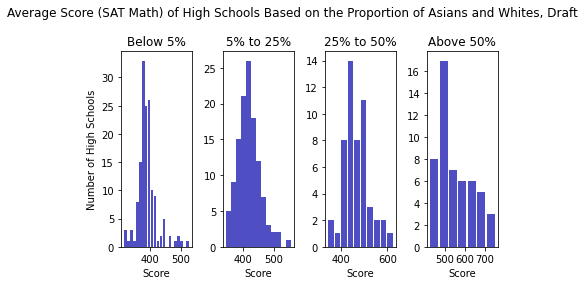

```python
fig, axs = plt.subplots(1,4)
fig.suptitle("Average Score (SAT Math) of High Schools Based on the Proportion of Asians and Whites, Draft")
axs[0].hist(x=wa1["Average Score (SAT Math)"],bins='auto', color='#0504aa',alpha=0.7, rwidth=0.85)
axs[0].set_title('Below 5%')
axs[0].set_xlabel('Score')
axs[0].set_ylabel('Number of High Schools')

axs[1].hist(x=wa2["Average Score (SAT Math)"],bins='auto', color='#0504aa',alpha=0.7, rwidth=0.85)
axs[1].set_title('5% to 25%')
axs[1].set_xlabel('Score')


axs[2].hist(x=wa3["Average Score (SAT Math)"],bins='auto', color='#0504aa',alpha=0.7, rwidth=0.85)
axs[2].set_title('25% to 50%')
axs[2].set_xlabel('Score')


axs[3].hist(x=wa4["Average Score (SAT Math)"],bins='auto', color='#0504aa',alpha=0.7, rwidth=0.85)
axs[3].set_title('Above 50%')
axs[3].set_xlabel('Score')


fig.tight_layout()
```

This is the draft I make for the message visualization, it divides the high schools into 4 categories based on the proportion of Asian students and White Students, then it shows these schools' average SAT math scores in each category. But the draft has several visualization problems. For example, each histogram has different scales on its y-axis and x-axis, this problem would make the plots hard to compare. It is impossible to see which category has the highest mean score without looking at the scale carefully. Moreover, it would be better to turn off right and top axis lines since they serve no purpose here.

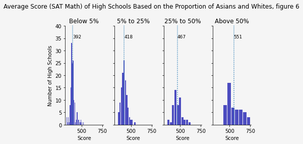

```python
fig, axs = plt.subplots(1,4)
fig.suptitle("Average Score (SAT Math) of High Schools Based on the Proportion of Asians and Whites, figure 6")
axs[0].hist(x=wa1["Average Score (SAT Math)"],bins='auto', color='#0504aa',alpha=0.7, rwidth=0.85)
axs[0].set_title('Below 5%')
axs[0].set_xlabel('Score')
axs[0].set_ylabel('Number of High Schools')
axs[0].spines['right'].set_visible(False)
axs[0].spines['top'].set_visible(False)
axs[0].set_xlim(300,760)
axs[0].set_ylim(0,40)
axs[0].set_facecolor((0.96, 0.96, 0.96))
axs[0].axvline(quant_50_1,alpha = 1, linestyle = ":")
axs[0].text(quant_50_1, y=35, s = str(round(quant_50_1)), size = 9, alpha = 1)

axs[1].hist(x=wa2["Average Score (SAT Math)"],bins='auto', color='#0504aa',alpha=0.7, rwidth=0.85)
axs[1].set_title('5% to 25%')
axs[1].set_xlabel('Score')
axs[1].spines['right'].set_visible(False)
axs[1].spines['top'].set_visible(False)
axs[1].set_facecolor((0.96, 0.96, 0.96))
axs[1].set_xlim(300,760)
axs[1].set_ylim(0,40)
axs[1].yaxis.set_ticklabels([])
axs[1].axvline(quant_50_2, alpha = 1, linestyle = ":")
axs[1].text(quant_50_2, y=35, s = str(round(quant_50_2)), size = 9, alpha = 1)

axs[2].hist(x=wa3["Average Score (SAT Math)"],bins='auto', color='#0504aa',alpha=0.7, rwidth=0.85)
axs[2].set_title('25% to 50%')
axs[2].set_xlabel('Score')
axs[2].spines['right'].set_visible(False)
axs[2].spines['top'].set_visible(False)
axs[2].set_facecolor((0.96, 0.96, 0.96))
axs[2].set_xlim(300,760)
axs[2].set_ylim(0,40)
axs[2].yaxis.set_ticklabels([])
axs[2].axvline(quant_50_3,alpha = 1, linestyle = ":")
axs[2].text(quant_50_3, y=35, s = str(round(quant_50_3)), size = 9, alpha = 1)

axs[3].yaxis.set_ticklabels([])
axs[3].hist(x=wa4["Average Score (SAT Math)"],bins='auto', color='#0504aa',alpha=0.7, rwidth=0.85)
axs[3].set_title('Above 50%')
axs[3].set_xlabel('Score')
axs[3].spines['right'].set_visible(False)
axs[3].spines['top'].set_visible(False)
axs[3].set_facecolor((0.96, 0.96, 0.96))
axs[3].set_xlim(300,760)
axs[3].set_ylim(0,40)
axs[3].yaxis.set_ticklabels([])
axs[3].axvline(quant_50_4,alpha = 1, linestyle = ":")
axs[3].text(quant_50_4, y=35, s = str(round(quant_50_4)), size = 9, alpha = 1)

fig.set_facecolor((0.96, 0.96, 0.96))
fig.tight_layout()
```

This is the fine-tuned version of the draft, it shows the distribution of high school's average SAT math score and the schools are divided into groups based on their proportion of Asian students and White students. From the figure, we could see a clear right shift of distribution as the proportion of Asians and Whites increases. For schools that have less than 5% of Asians and Whites, the mean of their distribution is 392, and most schools have an average SAT math score of less than 500. When it comes to 25% to 50%, the average scores of the majority of schools are still below 500, but it is obvious that much more schools have exceeded 500 or very close to 500. In addition to that, schools that have more than 50% of Asians and Whites, have a mean score of 551. The average scores of some schools even exceed 700. The result strongly suggests that high schools have higher average scores in SAT math if they have a higher proportion of Asian students and White students, which supports the result from figure 5.

```python
sum_BH = sat_data["Percent Black"] + sat_data["Percent Hispanic"]
sat_data["Percent Black & Hispanic"] = sum_BH
wa_50 = sat_data["Percent Black & Hispanic"] <= 0.50
wa1 = sat_data[wa_50]
avg_50_1 = wa1['Average Score (SAT Math)'].mean()

wa_70 = sat_data["Percent Black & Hispanic"] <= 0.70
wa2 = sat_data[wa_70]
wa2 = wa2[wa2["Percent Black & Hispanic"] > 0.50]
avg_50_2 = wa2['Average Score (SAT Math)'].mean()

wa_90 = sat_data["Percent Black & Hispanic"] <= 0.90
wa3 = sat_data[wa_90]
wa3 = wa3[wa3["Percent Black & Hispanic"] > 0.70]
avg_50_3 = wa3['Average Score (SAT Math)'].mean()

wa_91 = sat_data["Percent Black & Hispanic"] > 0.90
wa4 = sat_data[wa_91]
avg_50_4 = wa4['Average Score (SAT Math)'].mean()
```

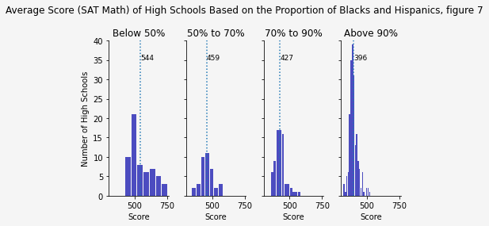

```python
fig, axs = plt.subplots(1,4)
fig.suptitle("Average Score (SAT Math) of High Schools Based on the Proportion of Blacks and Hispanics, figure 7")
axs[0].hist(x=wa1["Average Score (SAT Math)"],bins='auto', color='#0504aa',alpha=0.7, rwidth=0.85)
axs[0].set_title('Below 50%')
axs[0].set_xlabel('Score')
axs[0].set_ylabel('Number of High Schools')
axs[0].spines['right'].set_visible(False)
axs[0].spines['top'].set_visible(False)
axs[0].set_xlim(300,760)
axs[0].set_ylim(0,40)
axs[0].set_facecolor((0.96, 0.96, 0.96))
axs[0].axvline(avg_50_1,alpha = 1, linestyle = ":")
axs[0].text(avg_50_1, y=35, s = str(round(avg_50_1)), size = 9, alpha = 1)

axs[1].hist(x=wa2["Average Score (SAT Math)"],bins='auto', color='#0504aa',alpha=0.7, rwidth=0.85)
axs[1].set_title('50% to 70%')
axs[1].set_xlabel('Score')
axs[1].spines['right'].set_visible(False)
axs[1].spines['top'].set_visible(False)
axs[1].set_facecolor((0.96, 0.96, 0.96))
axs[1].set_xlim(300,760)
axs[1].set_ylim(0,40)
axs[1].yaxis.set_ticklabels([])
axs[1].axvline(avg_50_2,alpha = 1, linestyle = ":")
axs[1].text(avg_50_2, y=35, s = str(round(avg_50_2)), size = 9, alpha = 1)

axs[2].hist(x=wa3["Average Score (SAT Math)"],bins='auto', color='#0504aa',alpha=0.7, rwidth=0.85)
axs[2].set_title('70% to 90%')
axs[2].set_xlabel('Score')
axs[2].spines['right'].set_visible(False)
axs[2].spines['top'].set_visible(False)
axs[2].set_facecolor((0.96, 0.96, 0.96))
axs[2].set_xlim(300,760)
axs[2].set_ylim(0,40)
axs[2].yaxis.set_ticklabels([])
axs[2].axvline(avg_50_3,alpha = 1, linestyle = ":")
axs[2].text(avg_50_3, y=35, s = str(round(avg_50_3)), size = 9, alpha = 1)

axs[3].yaxis.set_ticklabels([])
axs[3].hist(x=wa4["Average Score (SAT Math)"],bins='auto', color='#0504aa',alpha=0.7, rwidth=0.85)
axs[3].set_title('Above 90%')
axs[3].set_xlabel('Score')
axs[3].spines['right'].set_visible(False)
axs[3].spines['top'].set_visible(False)
axs[3].set_facecolor((0.96, 0.96, 0.96))
axs[3].set_xlim(300,760)
axs[3].set_ylim(0,40)
axs[3].yaxis.set_ticklabels([])
axs[3].axvline(avg_50_4,alpha = 1, linestyle = ":")
axs[3].text(avg_50_4, y=35, s = str(round(avg_50_4)), size = 9, alpha = 1)

fig.set_facecolor((0.96, 0.96, 0.96))
fig.tight_layout()
```

Figure 7 is a similar version of figure 6, but it divides high schools according to their proportion of Black students and Hispanic students. The results of figure 6 are the opposite of figure 7, the schools which have more Blacks and Hispanics have on average lower SAT math scores. It suggests that the proportion of Black students and Hispanic students are negatively correlated with the school's average SAT math scores.

## Map

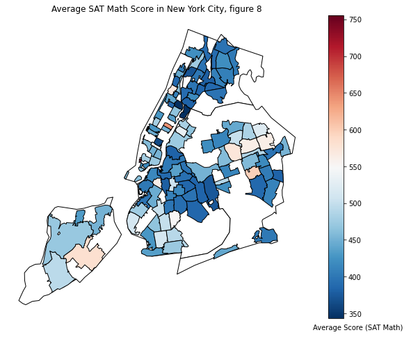

```python
county_df = gpd.read_file("http://www2.census.gov/geo/tiger/GENZ2016/shp/cb_2016_us_county_5m.zip")
county_df = county_df.query("STATEFP == '36'")

Manhattan = county_df.query("COUNTYFP == '061'")
Bronx = county_df.query("COUNTYFP == '005'")
Brooklyn = county_df.query("COUNTYFP == '047'")
Queens = county_df.query("COUNTYFP == '081'")
Staten = county_df.query("COUNTYFP == '085'")

nyc = pd.concat([Manhattan, Bronx, Brooklyn, Queens, Staten ], axis=0)

zipcode = gpd.read_file("http://www2.census.gov/geo/tiger/GENZ2019/shp/cb_2019_us_zcta510_500k.zip")
zipcode["ZCTA5CE10"] = zipcode["ZCTA5CE10"].apply(pd.to_numeric)

avg_stat = sat_data.groupby('Zip Code')
avg_stat = avg_stat.mean().reset_index()
nyc_sat = zipcode.merge(avg_stat, left_on="ZCTA5CE10", right_on="Zip Code", how="right")

fig, gax = plt.subplots(figsize = (10,8))

# Plot the state
nyc[nyc['LSAD'] == '06'].plot(ax = gax, edgecolor='black',color='white')

# Plot the counties and pass 'rel_trump_share' as the data to color
nyc_sat.plot(
    ax=gax, edgecolor='black', column='Average Score (SAT Math)', legend=True, cmap='RdBu_r',
    vmin=343, vmax=755 #range of your column value for the color legend
)

# Add text to let people know what we are plotting
gax.annotate('Average Score (SAT Math)',xy=(0.76, 0.06),  xycoords='figure fraction')
gax.set_title('Average SAT Math Score in New York City, figure 8')
# I don't want the axis with long and lat
plt.axis('off')

plt.show()
```

Figure 8 shows the average SAT math score by zip code in New York City. Each coloured region reflects the average SAT math score of all accredited high schools in that region. The blank areas are those zip-code regions where have no accredited high school according to the NYC Open Data. From the map, we could see that the SAT math score varies a lot across regions. Thus, it would be important to know the schools' race composition in each region to further conduct our study

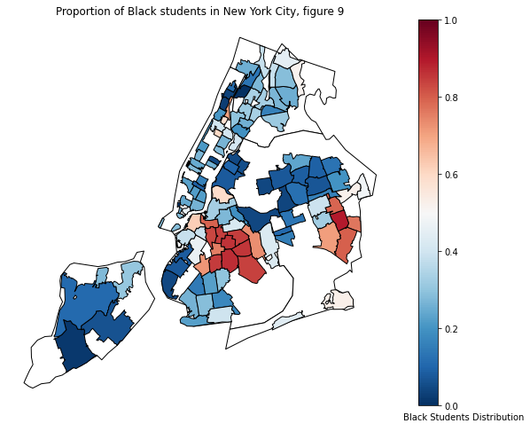

```python
fig, gax = plt.subplots(figsize = (10,8))

# Plot the state
nyc[nyc['LSAD'] == '06'].plot(ax = gax, edgecolor='black',color='white')

# Plot the counties and pass 'rel_trump_share' as the data to color
nyc_sat.plot(
    ax=gax, edgecolor='black', column='Percent Black', legend=True, cmap='RdBu_r',
    vmin=0, vmax=1 #range of your column value for the color legend
)

# Add text to let people know what we are plotting
gax.annotate('Black Students Distribution',xy=(0.76, 0.06),  xycoords='figure fraction')
gax.set_title('Proportion of Black students in New York City, figure 9')
# I don't want the axis with long and lat
plt.axis('off')

plt.show()
```

Figure 9 shows the average proportion of black students in each zip-code region. Compared to figure 8, it is clear that the red region in the middle of figure 9 corresponds to the dark blue region in the middle of figure 8, which indicates that there are lots of black students in regions where have very low SAT math average. And all non-blue regions in figure 8 corresponds to the dark blue region in figure 9, which means the high SAT math average regions have very few Black students. The evidence from the map supports my previous finding that the proportion of Black students negatively associated with the high school's average SAT math score.

```python
nyc_sat = nyc_sat.rename(columns={"Average Score (SAT Math)": "Math", "Zip Code" : "ZIP", "Percent White" : "White", "Percent Black" : "Black", "Percent Asian" : "Asian","Percent Hispanic" : "Hispanic"})

#Convert data to geojson for bokeh
wi_geojson=GeoJSONDataSource(geojson=nyc_sat.to_json())
```

```python
color_mapper = LinearColorMapper(palette = brewer['RdBu'][10], low = 343, high = 755)
color_bar = ColorBar(color_mapper=color_mapper, label_standoff=8,width = 500, height = 20,
                     border_line_color=None,location = (0,0), orientation = 'horizontal')
hover = HoverTool(tooltips = [ ('SAT Math Score','@Math'),('Zip Code', '@ZIP'),('White Proportion', '@White'),('Black Proportion', '@Black'),('Asian Proportion', '@Asian'),('Hispanic Proportion', '@Hispanic')])
p = figure(title="Average Score (SAT Math) in NYC by zip code, figure 10", tools=[hover])
p.patches("xs","ys",source=wi_geojson,
          fill_color = {'field' :'Math', 'transform' : color_mapper})
p.yaxis.axis_label = "latitude"
p.yaxis.axis_label_text_font_style = "italic"

p.xaxis.axis_label = "longitude"
p.xaxis.axis_label_text_font_style = "italic"

p.grid.axis = None

p.add_layout(color_bar, 'below')
show(p)
```

[interactive chart not shown]

This map also shows the average SAT math score by zip code in New York City, but it adds a feature that could provide each region's average SAT math score, school race composition and zip code specifically. According to the map, all non-blue regions have at least 20% of Asian students and most of them have at least 10% of White students. The reddest region has on average 73% of students as Asian and 93% of students as Asian or White, the second reddest region has on average 61% of students as White and a total of 81% of students as Asian or White. However, none of the darkest blue regions has on average more than 1% of students as Asian or White. And most of the second darkest blue region follows the same pattern as the darkest blue regions. Moreover, the proportion of Asian students and White students is larger than the proportion of Blacks and Hispanics in the majority of regions that have an average SAT math score of above 500. The map suggests strong evidence of how the race composition of a high school related to the school's average SAT math score, that the proportion of Asian students and White students of a high school positively correlate with the high school's average SAT math score, and it is the opposite for the proportion of Black students and Hispanic students.

## Future Step

So far, this analysis only uses the result from different visualizations (scatter plot, histogram, map) to study the association between a high school's race composition and the school's average SAT math score. The next step would be using linear regression which predicts a school's average SAT math score using the school's race composition. Moreover, we might need another dataset that allows us to add some control variables into the regression (income, crime rate, etc...). And some literature related to this topic needs to be reviewed to decide the final choice of control variables. The method of regression would provide us with some statistical evidence that helps this study.

## Conclusion

In this analysis, I study the association between high school's race composition and the school's average SAT math score by using different types of visualization includes histograms, scatter plots and maps. The study uses the data from NYC Open Data which contains relevant information of every accredited high school in New York City. The results of all visualizations are consistent with the idea that the proportion of Asian students and White students positively correlated with the school's average SAT math score, and the proportion of Black students and Hispanic students negatively correlated with the school's average score. But the finding in this analysis has not been supported by strong statistical evidence, method such as regression should be used for further investigation.